# Social Media MVA

2024-03-29

```r
library(readxl)
social_media <- read_excel("C:/Users/Vishal/Downloads/MVA_CLASS_COMBINE.xlsx")
```

[output not shown]

```r
str(social_media)
```

```
## tibble [21 × 25] (S3: tbl_df/tbl/data.frame)
##  $ Enter 5 character id ( not your net id, or your name). It should be same throughout the survey.: chr [1:21] "masinl" "peace" "Patty" "Bunny" ...
##  $ Instagram                                                                                      : chr [1:21] "Yes" "Yes" "Yes" "Yes" ...
##  $ Hours spent (HH:MM)
## Input N/A if not a user...3                                             : chr [1:21] "3.5" "0.32222222222222224" "0.15694444444444444" "0.22430555555555556" ...
##  $ Linkedin                                                                                       : chr [1:21] "Yes" "Yes" "Yes" "Yes" ...
##  $ Hours spent (HH:MM)
## Input N/A if not a user...5                                             : chr [1:21] "4" "0.21666666666666667" "0.29166666666666669" "0.22152777777777777" ...
##  $ Snapchat                                                                                       : chr [1:21] "Yes" "Yes" "Yes" "Yes" ...
##  $ Hours spent (HH:MM)
## Input N/A if not a user...7                                             : chr [1:21] "1" "0.15347222222222223" "2.2222222222222223E-2" "5.4166666666666669E-2" ...
##  $ Twitter                                                                                        : chr [1:21] "Yes" "No" "No" "No" ...
##  $ Hours spent (HH:MM)
## Input N/A if not a user...9                                             : chr [1:21] "5" "0" "N/A" "N/A" ...
##  $ Whatsapp/ Wechat                                                                               : chr [1:21] "Yes" "Yes" "Yes" "Yes" ...
```

[output cut: 19 more lines]

```r
social_media_cleaned <- social_media[,-1]
```

```r
#changing column names
change_cols_index <- c(2,4,6,8,10,12,14,16,17,18,19,20,21,22,23,24)
change_cols_name <- c("Instagram_Time", "Linkedin_Time", "Snapchat_Time", "Twitter_Time", "Whatsapp_Time", "Youtube_Time", "OTT_Time", "Reddit_Time", "Application Type", "Interview_call_received", "Networking", "Learning", "Mood_Productivity", "Morning_tireness", "Sleep_trouble", "Weekly_Feelings")
colnames(social_media_cleaned)[change_cols_index] <- change_cols_name



social_media_cleaned
```

```
## # A tibble: 21 × 24
##    Instagram Instagram_Time        Linkedin Linkedin_Time Snapchat Snapchat_Time
##    <chr>     <chr>                 <chr>    <chr>         <chr>    <chr>
##  1 Yes       3.5                   Yes      4             Yes      1
##  2 Yes       0.32222222222222224   Yes      0.2166666666… Yes      0.1534722222…
##  3 Yes       0.15694444444444444   Yes      0.2916666666… Yes      2.2222222222…
##  4 Yes       0.22430555555555556   Yes      0.2215277777… Yes      5.4166666666…
##  5 No        N/A                   Yes      2.4305555555… No       N/A
##  6 Yes       9.7222222222222224E-2 Yes      0.2916666666… Yes      1.9444444444…
##  7 yes       0.22361111111111112   yes      0.1666666666… No       <NA>
##  8 Yes       0.29166666666666669   Yes      0.1666666666… Yes      0.125
##  9 Yes       0.36041666666666666   Yes      10:00         Yes      03:50
## 10 Yes       6.9444444444444441E-3 Yes      0             No       N/A
## # ℹ 11 more rows
## # ℹ 18 more variables: Twitter <chr>, Twitter_Time <chr>,
## #   `Whatsapp/ Wechat` <chr>, Whatsapp_Time <chr>, Youtube <chr>,
## #   Youtube_Time <chr>, `OTT (Netflix, Hulu, Prime video)` <chr>,
## #   OTT_Time <chr>, Reddit <chr>, Reddit_Time <chr>, `Application Type` <chr>,
## #   Interview_call_received <chr>, Networking <chr>, Learning <dbl>,
## #   Mood_Productivity <chr>, Morning_tireness <chr>, Sleep_trouble <chr>, …
```

```r
# Convert "NA", "N/A", "n/a", "na", "N.A", "n.a" to 0
social_media_cleaned[social_media_cleaned == "NA" | social_media_cleaned == "N/A" | social_media_cleaned == "na" | social_media_cleaned == "n/a" | social_media_cleaned == "N.A" | social_media_cleaned == "n.a" | social_media_cleaned == "0" | social_media_cleaned == ""] <- NA
social_media_cleaned
```

```
## # A tibble: 21 × 24
##    Instagram Instagram_Time        Linkedin Linkedin_Time Snapchat Snapchat_Time
##    <chr>     <chr>                 <chr>    <chr>         <chr>    <chr>
##  1 Yes       3.5                   Yes      4             Yes      1
##  2 Yes       0.32222222222222224   Yes      0.2166666666… Yes      0.1534722222…
##  3 Yes       0.15694444444444444   Yes      0.2916666666… Yes      2.2222222222…
##  4 Yes       0.22430555555555556   Yes      0.2215277777… Yes      5.4166666666…
##  5 No        <NA>                  Yes      2.4305555555… No       <NA>
##  6 Yes       9.7222222222222224E-2 Yes      0.2916666666… Yes      1.9444444444…
##  7 yes       0.22361111111111112   yes      0.1666666666… No       <NA>
##  8 Yes       0.29166666666666669   Yes      0.1666666666… Yes      0.125
##  9 Yes       0.36041666666666666   Yes      10:00         Yes      03:50
## 10 Yes       6.9444444444444441E-3 Yes      <NA>          No       <NA>
## # ℹ 11 more rows
## # ℹ 18 more variables: Twitter <chr>, Twitter_Time <chr>,
## #   `Whatsapp/ Wechat` <chr>, Whatsapp_Time <chr>, Youtube <chr>,
## #   Youtube_Time <chr>, `OTT (Netflix, Hulu, Prime video)` <chr>,
## #   OTT_Time <chr>, Reddit <chr>, Reddit_Time <chr>, `Application Type` <chr>,
## #   Interview_call_received <chr>, Networking <chr>, Learning <dbl>,
## #   Mood_Productivity <chr>, Morning_tireness <chr>, Sleep_trouble <chr>, …
```

```r
social_media_cleaned[is.na(social_media_cleaned)] <- '0'
social_media_cleaned
```

```
## # A tibble: 21 × 24
##    Instagram Instagram_Time        Linkedin Linkedin_Time Snapchat Snapchat_Time
##    <chr>     <chr>                 <chr>    <chr>         <chr>    <chr>
##  1 Yes       3.5                   Yes      4             Yes      1
##  2 Yes       0.32222222222222224   Yes      0.2166666666… Yes      0.1534722222…
##  3 Yes       0.15694444444444444   Yes      0.2916666666… Yes      2.2222222222…
##  4 Yes       0.22430555555555556   Yes      0.2215277777… Yes      5.4166666666…
##  5 No        0                     Yes      2.4305555555… No       0
##  6 Yes       9.7222222222222224E-2 Yes      0.2916666666… Yes      1.9444444444…
##  7 yes       0.22361111111111112   yes      0.1666666666… No       0
##  8 Yes       0.29166666666666669   Yes      0.1666666666… Yes      0.125
##  9 Yes       0.36041666666666666   Yes      10:00         Yes      03:50
## 10 Yes       6.9444444444444441E-3 Yes      0             No       0
## # ℹ 11 more rows
## # ℹ 18 more variables: Twitter <chr>, Twitter_Time <chr>,
## #   `Whatsapp/ Wechat` <chr>, Whatsapp_Time <chr>, Youtube <chr>,
## #   Youtube_Time <chr>, `OTT (Netflix, Hulu, Prime video)` <chr>,
## #   OTT_Time <chr>, Reddit <chr>, Reddit_Time <chr>, `Application Type` <chr>,
## #   Interview_call_received <chr>, Networking <chr>, Learning <dbl>,
## #   Mood_Productivity <chr>, Morning_tireness <chr>, Sleep_trouble <chr>, …
```

```r
# Define a function to convert time strings to decimal hours
convert_to_decimal_hours <- function(time_string) {
# Check if NA values are present
if (any(is.na(time_string))) {
         return(rep(NA, length(time_string)))  # Return NA for NA values
     }

# Define a function to convert HH:MM format to decimal hours
     hhmm_to_decimal <- function(hhmm) {
         parts <- as.numeric(strsplit(hhmm, ":")[[1]])  # Split into hours and minutes
         hours <- parts[1]
         minutes <- ifelse(length(parts) > 1, parts[2], 0)  # Handle missing minutes
         total_hours <- hours + minutes / 60
         return(total_hours)
     }

# Convert time strings to decimal hours
decimal_hours <- sapply(time_string, function(x) {
         if (grepl("^\\d+:\\d+$", x)) {
             return(hhmm_to_decimal(x))  # Convert HH:MM format
         } else if (grepl("^\\d+\\.\\d+$", x)) {
             return(as.numeric(x))  # Convert decimal format
         } else if (grepl("^\\d+$", x)) {
             return(as.numeric(x))  # Convert whole numbers
         } else {
             return(NA)  # Return NA for other cases
         }
     })

     return(decimal_hours)
}

time_columns <- c("Instagram_Time", "Linkedin_Time", "Snapchat_Time", "Twitter_Time", "Whatsapp_Time", "Youtube_Time", "OTT_Time", "Reddit_Time")
# Apply the conversion function to all time columns
social_media_cleaned[time_columns] <- lapply(social_media_cleaned[time_columns], convert_to_decimal_hours)

# Verify the result
str(social_media_cleaned)
```

```
## tibble [21 × 24] (S3: tbl_df/tbl/data.frame)
##  $ Instagram                       : chr [1:21] "Yes" "Yes" "Yes" "Yes" ...
##  $ Instagram_Time                  : Named num [1:21] 3.5 0.322 0.157 0.224 0 ...
##   ..- attr(*, "names")= chr [1:21] "3.5" "0.32222222222222224" "0.15694444444444444" "0.22430555555555556" ...
##  $ Linkedin                        : chr [1:21] "Yes" "Yes" "Yes" "Yes" ...
##  $ Linkedin_Time                   : Named num [1:21] 4 0.217 0.292 0.222 NA ...
##   ..- attr(*, "names")= chr [1:21] "4" "0.21666666666666667" "0.29166666666666669" "0.22152777777777777" ...
##  $ Snapchat                        : chr [1:21] "Yes" "Yes" "Yes" "Yes" ...
##  $ Snapchat_Time                   : Named num [1:21] 1 0.153 NA NA 0 ...
##   ..- attr(*, "names")= chr [1:21] "1" "0.15347222222222223" "2.2222222222222223E-2" "5.4166666666666669E-2" ...
##  $ Twitter                         : chr [1:21] "Yes" "No" "No" "No" ...
##  $ Twitter_Time                    : Named num [1:21] 5 0 0 0 NA 0 0 0 0 0 ...
##   ..- attr(*, "names")= chr [1:21] "5" "0" "0" "0" ...
##  $ Whatsapp/ Wechat                : chr [1:21] "Yes" "Yes" "Yes" "Yes" ...
##  $ Whatsapp_Time                   : Named num [1:21] 1 0.174 0.41 0.221 0.125 ...
```

[output cut: 18 more lines]

```r
#Dropping the name columns
social_media_cleaned <- social_media_cleaned[, -c(1, 3, 5, 7, 9, 11, 13, 15)]
social_media_cleaned
```

```
## # A tibble: 21 × 16
##    Instagram_Time Linkedin_Time Snapchat_Time Twitter_Time Whatsapp_Time
##             <dbl>         <dbl>         <dbl>        <dbl>         <dbl>
##  1          3.5           4             1                5         1
##  2          0.322         0.217         0.153            0         0.174
##  3          0.157         0.292        NA                0         0.410
##  4          0.224         0.222        NA                0         0.221
##  5          0            NA             0               NA         0.125
##  6         NA             0.292        NA                0         0.5
##  7          0.224         0.167         0                0         0.25
##  8          0.292         0.167         0.125            0         0.417
##  9          0.360        10             3.83             0         6.15
## 10         NA             0             0                0        NA
## # ℹ 11 more rows
## # ℹ 11 more variables: Youtube_Time <dbl>, OTT_Time <dbl>, Reddit_Time <dbl>,
## #   `Application Type` <chr>, Interview_call_received <chr>, Networking <chr>,
## #   Learning <dbl>, Mood_Productivity <chr>, Morning_tireness <chr>,
## #   Sleep_trouble <chr>, Weekly_Feelings <dbl>
```

```r
# Loop through each column in time_columns
social_media_cleaned[time_columns] <- lapply(social_media_cleaned[time_columns], function(x) {
  # Calculate mean of the column excluding NA values
  mean_value <- mean(x, na.rm = TRUE)
  # Replace NA values with the mean
  x[is.na(x)] <- mean_value
  return(x)
})

# Print the updated data frame
print(social_media_cleaned)
```

```
## # A tibble: 21 × 16
##    Instagram_Time Linkedin_Time Snapchat_Time Twitter_Time Whatsapp_Time
##             <dbl>         <dbl>         <dbl>        <dbl>         <dbl>
##  1          3.5           4             1            5             1
##  2          0.322         0.217         0.153        0             0.174
##  3          0.157         0.292         0.503        0             0.410
##  4          0.224         0.222         0.503        0             0.221
##  5          0             1.11          0            0.290         0.125
##  6          0.722         0.292         0.503        0             0.5
##  7          0.224         0.167         0            0             0.25
##  8          0.292         0.167         0.125        0             0.417
##  9          0.360        10             3.83         0             6.15
## 10          0.722         0             0            0             0.908
## # ℹ 11 more rows
## # ℹ 11 more variables: Youtube_Time <dbl>, OTT_Time <dbl>, Reddit_Time <dbl>,
## #   `Application Type` <chr>, Interview_call_received <chr>, Networking <chr>,
## #   Learning <dbl>, Mood_Productivity <chr>, Morning_tireness <chr>,
## #   Sleep_trouble <chr>, Weekly_Feelings <dbl>
```

```r
#Scaling the data
# Extracting the columns with names ending in "_Time"
time_columns <- grep("_Time$", names(social_media_cleaned), value = TRUE)

# Scaling the time columns
scaled_time_data <- scale(social_media_cleaned[time_columns])

#plotting the scaled values
x_time_columns <- grep("_Time$", names(social_media_cleaned), value = TRUE)
x_time_columns
```

```
## [1] "Instagram_Time" "Linkedin_Time"  "Snapchat_Time"  "Twitter_Time"
## [5] "Whatsapp_Time"  "Youtube_Time"   "OTT_Time"       "Reddit_Time"
```

Done With data cleaning above:

Lets start with our analysis

All the time parameters seem to be concentrated between -0.5 and 0

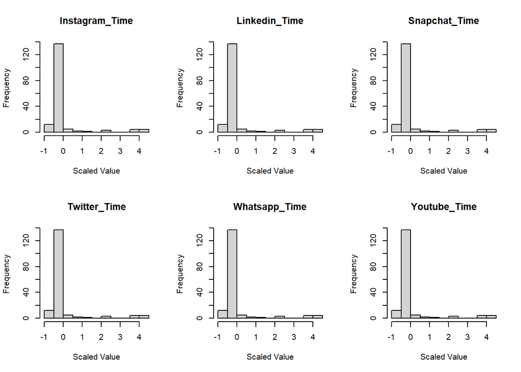

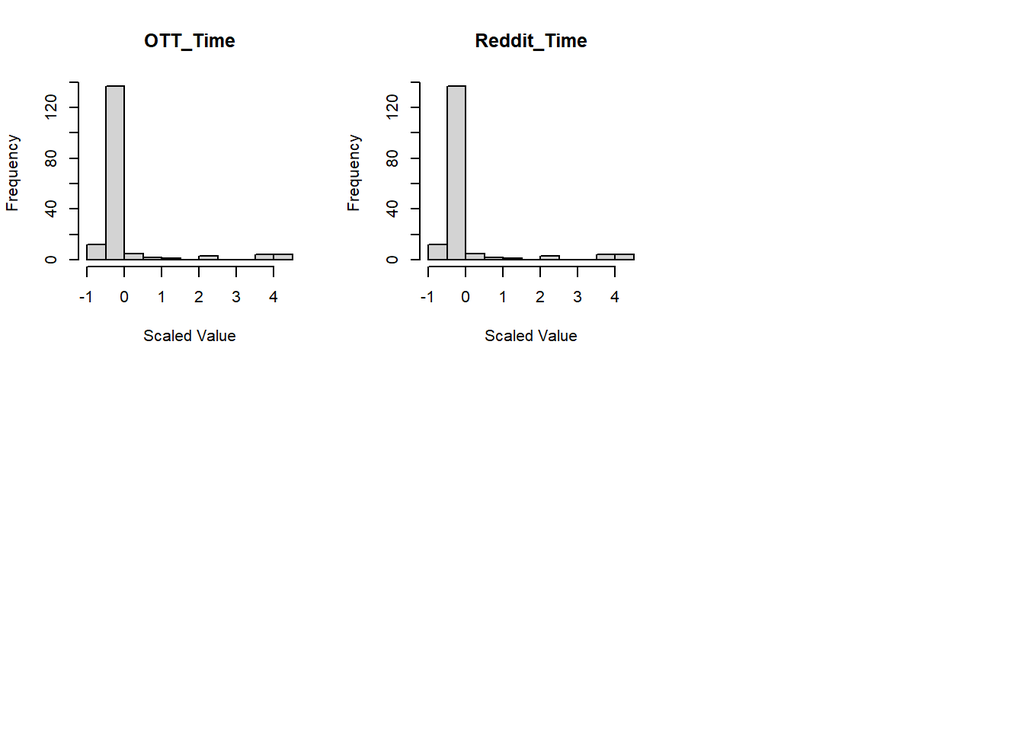

```r
# Plot histograms for each x_time column
par(mfrow = c(2, 3))

# Adjust the layout based on the number of x_time columns
for (col in x_time_columns) {
    hist(scaled_time_data, main = col, xlab = "Scaled Value")
}
```

```r
scaled_time_data
```

```
##       Instagram_Time Linkedin_Time Snapchat_Time Twitter_Time Whatsapp_Time
##  [1,]     2.18465722     1.2980023     0.6122052    4.3441693    0.06288835
##  [2,]    -0.31450386    -0.4025969    -0.4308111   -0.2674074   -0.50021542
##  [3,]    -0.44448645    -0.3688846     0.0000000   -0.2674074   -0.33966691
##  [4,]    -0.39151036    -0.4004118     0.0000000   -0.2674074   -0.46848459
##  [5,]    -0.56791530     0.0000000    -0.6199059    0.0000000   -0.53384062
##  [6,]     0.00000000    -0.3688846     0.0000000   -0.2674074   -0.27809963
##  [7,]    -0.39205650    -0.4250718    -0.6199059   -0.2674074   -0.44859362
##  [8,]    -0.33853426    -0.4250718    -0.4658920   -0.2674074   -0.33493096
##  [9,]    -0.28446587     3.9949878     4.1031869   -0.2674074    3.57506461
## [10,]     0.00000000    -0.4999880    -0.6199059   -0.2674074    0.00000000
## [11,]    -0.41772533     0.0000000     0.0000000   -0.1745354    0.00000000
## [12,]    -0.45868623    -0.4531654     0.0000000   -0.1585229   -0.51489684
## [13,]     3.60053901     0.1836229     0.1450298   -0.2674074    2.12302410
## [14,]    -0.37130298    -0.4438008     0.0000000    0.0000000   -0.52200076
```

[output cut: 39 more lines]

Correlation:

High Correlations:

There are strong positive correlations between time spent on various social media platforms, such as:

LinkedIn and Snapchat (0.926)

LinkedIn and YouTube (0.950)

Snapchat and YouTube (0.909)

Twitter and Reddit (0.985)

WhatsApp and LinkedIn (0.839)

Moderate Correlations:

There are moderate positive correlations between time spent on platforms like:

Twitter and YouTube (0.452)

Instagram and Twitter (0.483)

Low Correlations:

Some platforms have relatively low correlations with each other, such as: WhatsApp and Twitter (-0.006)

WhatsApp and OTT (0.120)

Snapchat and Instagram (0.099)

Interpretation:

Strong positive correlations indicate that users who spend more time on one platform are likely to spend more time on the correlated platform as well.

Negative correlations, though rare here, indicate that as time spent on one platform increases, time spent on the other decreases, or vice versa.

Low correlations suggest that the time spent on one platform doesn’t necessarily predict the time spent on another platform.

```r
#Performing PCA

# Compute the covariance matrix
cov_matrix <- cov(scaled_time_data)
cov_matrix
```

```
##                Instagram_Time Linkedin_Time Snapchat_Time Twitter_Time
## Instagram_Time     1.00000000     0.2001230    0.09945917  0.483441518
## Linkedin_Time      0.20012297     1.0000000    0.92634630  0.290890950
## Snapchat_Time      0.09945917     0.9263463    1.00000000  0.124584829
## Twitter_Time       0.48344152     0.2908909    0.12458483  1.000000000
## Whatsapp_Time      0.44894402     0.8391584    0.81147325 -0.005624872
## Youtube_Time       0.24621965     0.9504195    0.90919829  0.451912244
## OTT_Time           0.44920752     0.4351652    0.31112287  0.967902109
## Reddit_Time        0.52999793     0.2839576    0.13409125  0.984791846
##                Whatsapp_Time Youtube_Time  OTT_Time Reddit_Time
## Instagram_Time   0.448944024    0.2462197 0.4492075  0.52999793
## Linkedin_Time    0.839158354    0.9504195 0.4351652  0.28395760
## Snapchat_Time    0.811473248    0.9091983 0.3111229  0.13409125
## Twitter_Time    -0.005624872    0.4519122 0.9679021  0.98479185
## Whatsapp_Time    1.000000000    0.7419399 0.1196354  0.01868572
## Youtube_Time     0.741939888    1.0000000 0.5890963  0.44754901
## OTT_Time         0.119635420    0.5890963 1.0000000  0.96376316
## Reddit_Time      0.018685717    0.4475490 0.9637632  1.00000000
```

Eigenvalues:

Eigenvectors:

They represent the direction of principal components in the original feature space. Each column corresponds to a different principal component.

Inference:

The dominant eigenvalue suggests strong variability in the data’s first principal component. Eigenvectors provide insight into the direction of this variability. This decomposition aids dimensionality reduction, prioritizing principal components with higher eigenvalues for retaining data variance.

```r
# Perform eigenvalue decomposition
eigen_result <- eigen(cov_matrix)
eigen_result
```

```
## eigen() decomposition
## $values
## [1] 4.520473226 2.448935759 0.890914173 0.075809261 0.030334344 0.015178469
## [7] 0.011022759 0.007332008
##
## $vectors
##            [,1]       [,2]        [,3]        [,4]        [,5]        [,6]
## [1,] -0.2477471 -0.1880859  0.84132003 -0.21094798 -0.12839605 -0.15043237
## [2,] -0.4002537  0.3085881 -0.13157415  0.53314126  0.25146045 -0.06194170
## [3,] -0.3543206  0.3854248 -0.17423456 -0.71516362  0.22818425  0.09210725
## [4,] -0.3329341 -0.4412965 -0.11995870  0.21661133 -0.08471808 -0.27138684
## [5,] -0.3138458  0.4072617  0.39092063  0.29017730  0.22144674  0.14380318
## [6,] -0.4319795  0.2033958 -0.19645677 -0.02634729 -0.81044270 -0.08277380
## [7,] -0.3790209 -0.3539820 -0.18625604 -0.16691983  0.39275079 -0.43706986
## [8,] -0.3365529 -0.4399626 -0.06336853  0.01107272  0.03045781  0.82026693
##             [,7]       [,8]
## [1,]  0.26654226 -0.2019070
## [2,]  0.49340623 -0.3640057
## [3,]  0.26414492  0.2318699
## [4,]  0.26202502  0.6954255
## [5,] -0.53931677  0.3715324
## [6,] -0.21273896 -0.1542975
## [7,] -0.45844319 -0.3362037
## [8,] -0.02802253 -0.1203168
```

```r
# Extract eigenvalues and eigenvectors
eigenvalues <- eigen_result$values
eigenvalues
```

```
## [1] 4.520473226 2.448935759 0.890914173 0.075809261 0.030334344 0.015178469
## [7] 0.011022759 0.007332008
```

The magnitude of each eigenvalue reflects the amount of variability accounted for by its corresponding principal component.

Prioritizing principal components based on their eigenvalues guides dimensionality reduction techniques like PCA, preserving the most significant variability while reducing dimensionality.

```r
eigenvectors <- eigen_result$vectors
eigenvectors
```

```
##            [,1]       [,2]        [,3]        [,4]        [,5]        [,6]
## [1,] -0.2477471 -0.1880859  0.84132003 -0.21094798 -0.12839605 -0.15043237
## [2,] -0.4002537  0.3085881 -0.13157415  0.53314126  0.25146045 -0.06194170
## [3,] -0.3543206  0.3854248 -0.17423456 -0.71516362  0.22818425  0.09210725
## [4,] -0.3329341 -0.4412965 -0.11995870  0.21661133 -0.08471808 -0.27138684
## [5,] -0.3138458  0.4072617  0.39092063  0.29017730  0.22144674  0.14380318
## [6,] -0.4319795  0.2033958 -0.19645677 -0.02634729 -0.81044270 -0.08277380
## [7,] -0.3790209 -0.3539820 -0.18625604 -0.16691983  0.39275079 -0.43706986
## [8,] -0.3365529 -0.4399626 -0.06336853  0.01107272  0.03045781  0.82026693
##             [,7]       [,8]
## [1,]  0.26654226 -0.2019070
## [2,]  0.49340623 -0.3640057
## [3,]  0.26414492  0.2318699
## [4,]  0.26202502  0.6954255
## [5,] -0.53931677  0.3715324
## [6,] -0.21273896 -0.1542975
## [7,] -0.45844319 -0.3362037
## [8,] -0.02802253 -0.1203168
```

The number of principal components to consider is determined by counting the eigenvalues greater than 1.

In this case, there are 2 eigenvalues greater than 1, indicating that 2 principal components should be retained.

Principal components with eigenvalues above 1 explain more variance than individual variables and are thus considered significant for preserving the overall variability in the data.

Retaining these 2 principal components allows for dimensionality reduction while still capturing a substantial portion of the data’s variability.

```r
#To find number of principal components to consider:
#1 Eigenvalue criterion
eigenvalues <- eigen_result$values
num_components <- sum(eigenvalues > 1)
print(num_components)
```

```
## [1] 2
```

As per the Scree plot we can observe that ideally using 2 PCA’s is best as 2 points are above reference line and there is a strong elbow at 2nd PCA

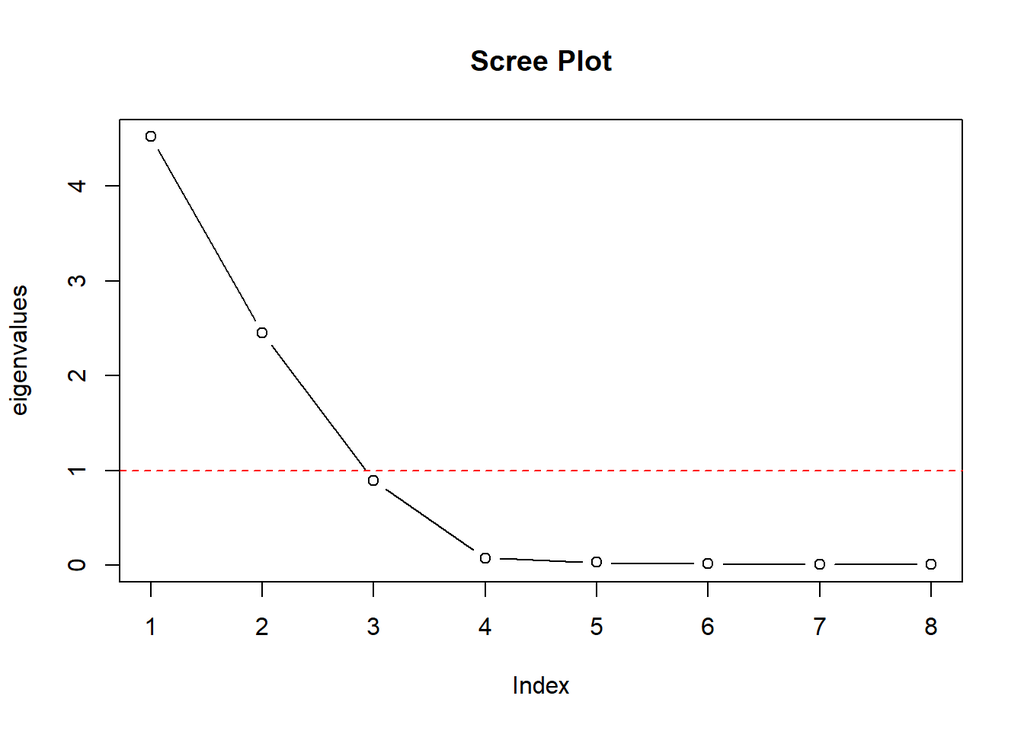

```r
#2 Scree plot
plot(eigenvalues, type = "b", main = "Scree Plot")
abline(h = 1, col = "red", lty = 2)
```

Each row corresponds to an observation, and each column represents a transformed feature.

The values in the transformed data represent the coordinates of observations in a new feature space defined by the first three principal components.

Retaining only three principal components achieves dimensionality reduction while preserving a significant portion of the original data’s variance.

In essence, the transformed data simplifies the original dataset into a lower-dimensional space, facilitating analysis while retaining essential patterns.

```r
#Retaining 3 PC
n_components <- 3
transformed_data <- scaled_time_data %*% eigenvectors[, 1:n_components]
print(transformed_data)
```

```
##             [,1]          [,2]        [,3]
##  [1,] -6.6770821 -4.6370290739 -0.39606253
##  [2,]  1.0875484 -0.1099261364 -0.11460180
##  [3,]  0.5494848  0.0750491682 -0.40803307
##  [4,]  0.5894079  0.0028936673 -0.40967253
##  [5,]  0.7194909 -0.4397383225 -0.49134133
##  [6,]  0.7060646  0.1082651040  0.12597233
##  [7,]  1.1903975 -0.1653587744 -0.11292190
##  [8,]  0.8704884  0.0106722962 -0.14927108
##  [9,] -5.6818898  5.1304248823 -0.84070762
## [10,]  0.9824629 -0.0795223315  0.40214463
## [11,]  0.4341265  0.4459846739 -0.22570587
## [12,]  0.8161555 -0.1668984452 -0.39464163
## [13,] -1.4696676  0.5196449229  3.90259331
## [14,]  0.7402102 -0.2532929851 -0.34414975
## [15,]  0.6143024 -0.3174807275 -0.35640422
## [16,]  0.6482406 -0.2147253635 -0.31161991
## [17,]  0.6430776 -0.2544547849 -0.08839228
## [18,]  0.5668149  0.2898818234 -0.32443426
## [19,]  1.1215689 -0.1146281761 -0.09069581
## [20,]  0.8037390 -0.0002174451  0.14785555
## [21,]  0.7450584  0.1704560281  0.48008978
```

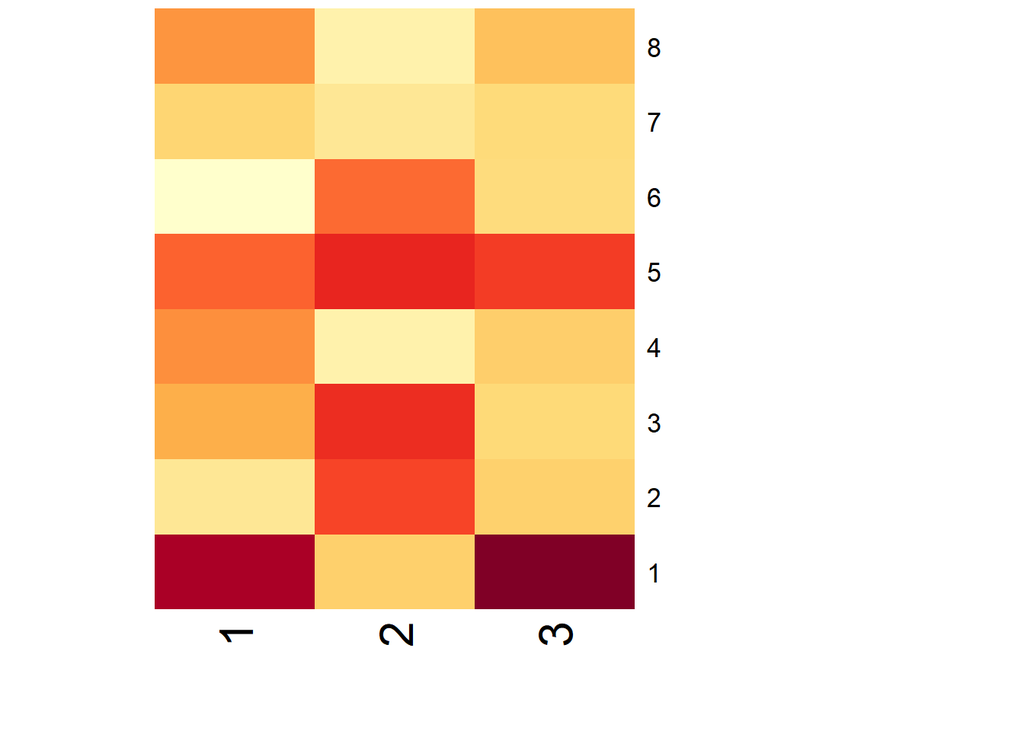

```r
library(RColorBrewer)
loadings <- eigenvectors[, 1:n_components]
my_palette <- colorRampPalette(brewer.pal(9, "YlOrRd"))
# Visualize the loadings matrix with the specified color palette
heatmap(loadings, Rowv = NA, Colv = NA, col = my_palette(256), scale = "column", margins = c(5, 10))
```

PC2 and PC2 seem to be concentrated above 0 towards positive and some outliers at minus and one above 4 value of PC1

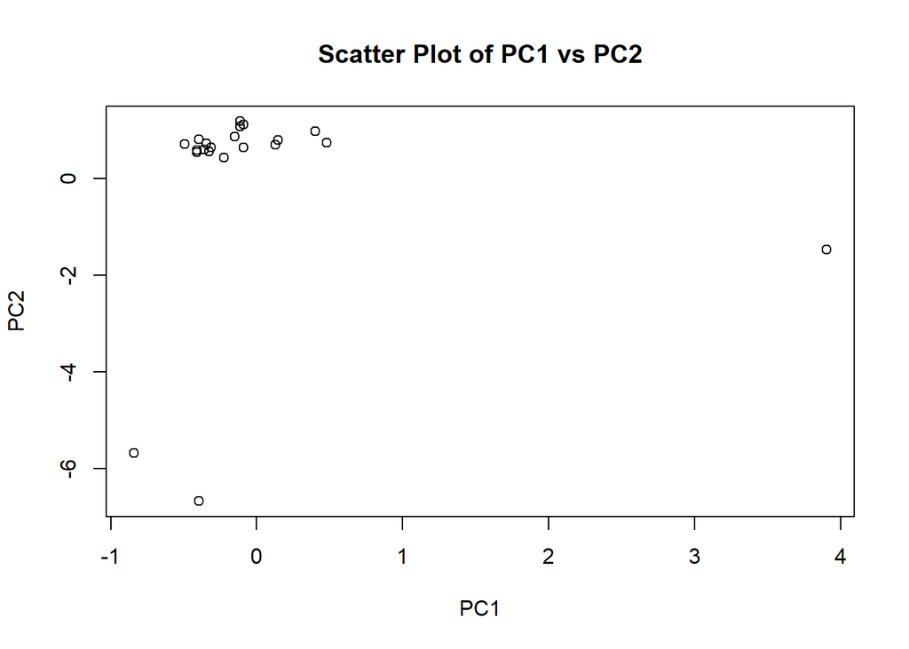

```r
# Scatter plot of the first two principal components
plot(transformed_data[, 3], transformed_data[, 1], xlab = "PC1", ylab = "PC2",
     main = "Scatter Plot of PC1 vs PC2")
```

Below bioplot infers that Insta, OTT and Twitter are highly correlated in PC2

Rest are negatively correlated in PC2 AND all values are towards neagtive of PC1

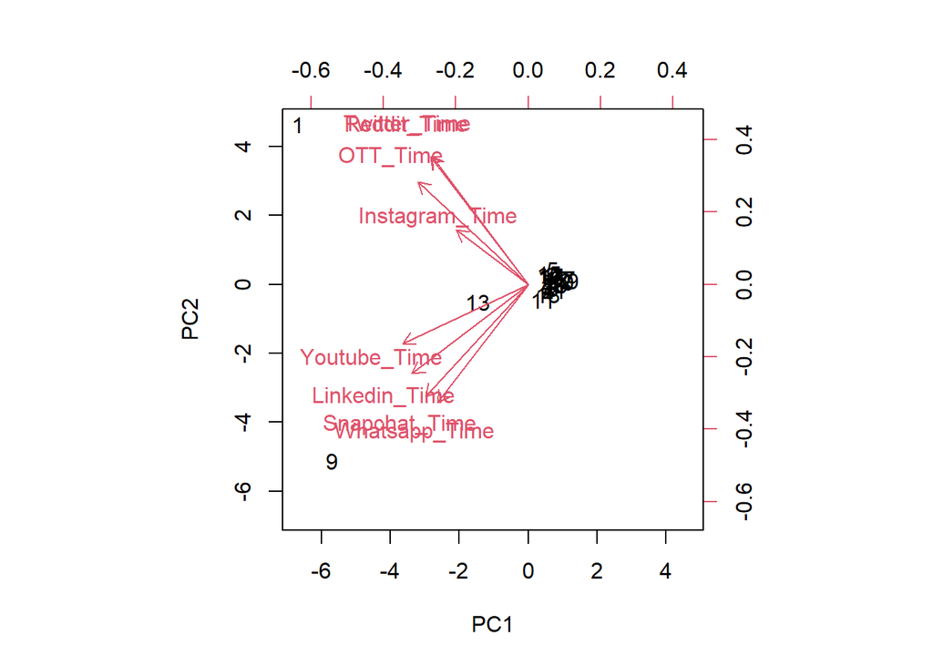

```r
biplot(prcomp(scaled_time_data), scale = 0)
```

Cumulative Variance Plot”:

Explains that best variance is observed till 3 PC’S

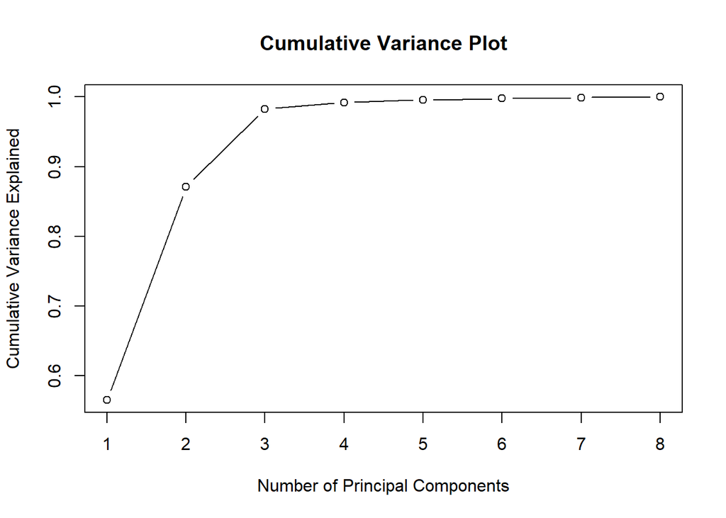

```r
# Cumulative Variance Plot
cumulative_variance <- cumsum(eigenvalues) / sum(eigenvalues)
plot(1:length(cumulative_variance), cumulative_variance, type = "b",
     xlab = "Number of Principal Components", ylab = "Cumulative Variance Explained",
     main = "Cumulative Variance Plot")
```

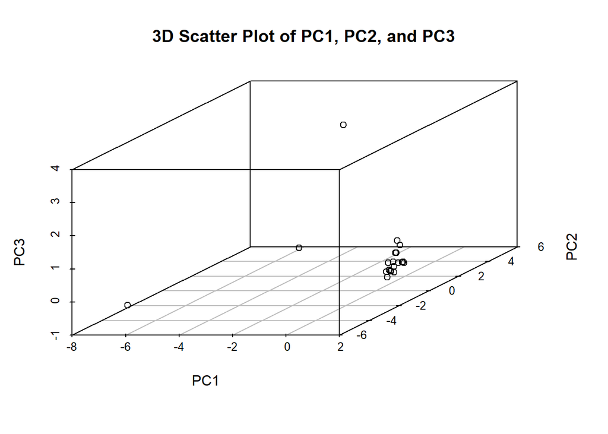

```r
# 3D Scatter Plot
library(scatterplot3d)
scatterplot3d(transformed_data[, 1], transformed_data[, 2], transformed_data[, 3],
              xlab = "PC1", ylab = "PC2", zlab = "PC3",
              main = "3D Scatter Plot of PC1, PC2, and PC3")
```

LinkedIn and Snapchat:

There is a strong positive correlation between the time spent on LinkedIn and Snapchat. Users who spend more time on LinkedIn are likely to spend a considerable amount of time on Snapchat, and vice versa. LinkedIn and YouTube:

A significant positive correlation exists between the time spent on LinkedIn and YouTube. Users who engage more with LinkedIn content are also likely to spend substantial time on YouTube, and vice versa. Snapchat and YouTube:

There is a strong positive correlation between the time spent on Snapchat and YouTube. Users who use Snapchat frequently are also likely to spend a significant amount of time on YouTube, and vice versa. Twitter and Reddit:

A very strong positive correlation exists between the time spent on Twitter and Reddit. Users who are active on Twitter tend to be similarly active on Reddit, and vice versa. WhatsApp and LinkedIn:

There is a notable positive correlation between the time spent on WhatsApp and LinkedIn. Users who dedicate more time to WhatsApp messaging also tend to spend considerable time on LinkedIn, and vice versa.

[figure not shown]

```r
# Heatmap of Correlation Matrix
corr_matrix <- cor(scaled_time_data)
heatmap(corr_matrix, Rowv = NA, Colv = NA, col = heat.colors(256))
```

```r
#Cluster Analysis

# Define the maximum number of clusters to test
max_k <- 10

# Perform K-means clustering for different values of k
wcss <- numeric(length = max_k)
for (i in 1:max_k) {
  kmeans_model <- kmeans(scaled_time_data, centers = i)
  wcss[i] <- kmeans_model$tot.withinss
}
```

As per the elbow plot Best output for k-means cluster is yielded at 3-4 clusters as elbow is present at that point

Sum of square used to check the performance

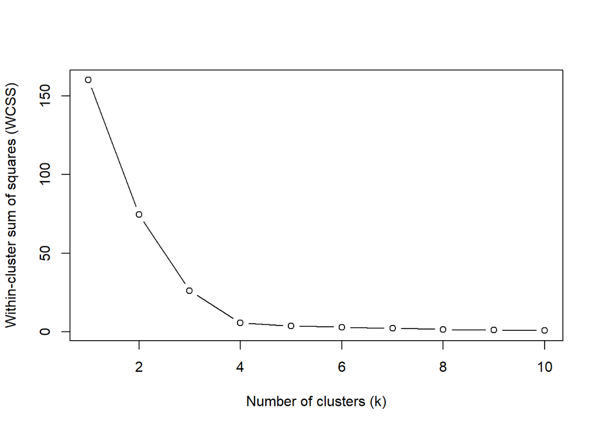

```r
# Plot the elbow method
plot(1:max_k, wcss, type = "b", xlab = "Number of clusters (k)", ylab = "Within-cluster sum of squares (WCSS)")
```

```r
# Convert scaled_time_data to numeric
scaled_time_data <- apply(scaled_time_data, 2, as.numeric)

# Assuming your data is stored in a matrix named 'scaled_time_data'
# Use max.col to get the index of the maximum value in each column
max_indices <- max.col(scaled_time_data, ties.method = "first")

# Create a vector to store the column names corresponding to the maximum values
max_column <- colnames(scaled_time_data)[max_indices]

# Add the max_column vector as a new column to the data matrix
social_media_data_with_max <- cbind(scaled_time_data, max_column)

# Verify the conversion
str(social_media_data_with_max)
```

```
##  chr [1:21, 1:9] "2.18465721631583" "-0.314503862712017" ...
##  - attr(*, "dimnames")=List of 2
##   ..$ : NULL
##   ..$ : chr [1:9] "Instagram_Time" "Linkedin_Time" "Snapchat_Time" "Twitter_Time" ...
```

```r
social_media_data_with_max
```

```
##       Instagram_Time        Linkedin_Time        Snapchat_Time
##  [1,] "2.18465721631583"    "1.29800231859365"   "0.612205244656956"
##  [2,] "-0.314503862712017"  "-0.40259688338968"  "-0.430811098086101"
##  [3,] "-0.444486453797818"  "-0.368884564407632" "0"
##  [4,] "-0.391510355750243"  "-0.400411825677881" "0"
##  [5,] "-0.56791530079526"   "0"                  "-0.619905939551414"
##  [6,] "0"                   "-0.368884564407632" "0"
##  [7,] "-0.39205650109094"   "-0.425071762711046" "-0.619905939551414"
##  [8,] "-0.338534257702669"  "-0.425071762711046" "-0.465892041525368"
##  [9,] "-0.284465868973701"  "3.99498783715751"   "4.10318693324734"
## [10,] "0"                   "-0.499988027115597" "-0.619905939551414"
## [11,] "-0.417725332103682"  "0"                  "0"
## [12,] "-0.458686232655931"  "-0.453165361862753" "0"
## [13,] "3.60053901189711"    "0.183622885426105"  "0.145029753936879"
## [14,] "-0.371302978144468"  "-0.443800828812184" "0"
```

[output cut: 51 more lines]

```r
# Assuming your data is stored in a matrix named 'social_media_data_with_max'

# Get the names of all columns
all_columns <- colnames(social_media_data_with_max)

# Convert all columns to numeric except max_column
for (col in names(social_media_data_with_max)) {
  if (col != "max_column") {
    social_media_data_with_max[, col] <- as.numeric(social_media_data_with_max[, col])
  }
}

# Verify the conversion
str(social_media_data_with_max)
```

```
##  chr [1:21, 1:9] "2.18465721631583" "-0.314503862712017" ...
##  - attr(*, "dimnames")=List of 2
##   ..$ : NULL
##   ..$ : chr [1:9] "Instagram_Time" "Linkedin_Time" "Snapchat_Time" "Twitter_Time" ...
```

```r
social_media_data_with_max
```

```
##       Instagram_Time        Linkedin_Time        Snapchat_Time
##  [1,] "2.18465721631583"    "1.29800231859365"   "0.612205244656956"
##  [2,] "-0.314503862712017"  "-0.40259688338968"  "-0.430811098086101"
##  [3,] "-0.444486453797818"  "-0.368884564407632" "0"
##  [4,] "-0.391510355750243"  "-0.400411825677881" "0"
##  [5,] "-0.56791530079526"   "0"                  "-0.619905939551414"
##  [6,] "0"                   "-0.368884564407632" "0"
##  [7,] "-0.39205650109094"   "-0.425071762711046" "-0.619905939551414"
##  [8,] "-0.338534257702669"  "-0.425071762711046" "-0.465892041525368"
##  [9,] "-0.284465868973701"  "3.99498783715751"   "4.10318693324734"
## [10,] "0"                   "-0.499988027115597" "-0.619905939551414"
## [11,] "-0.417725332103682"  "0"                  "0"
## [12,] "-0.458686232655931"  "-0.453165361862753" "0"
## [13,] "3.60053901189711"    "0.183622885426105"  "0.145029753936879"
## [14,] "-0.371302978144468"  "-0.443800828812184" "0"
```

[output cut: 51 more lines]

Cluster Centers: The cluster centers represent the average values of each variable (Instagram_Time, Linkedin_Time, Snapchat_Time, Twitter_Time, Whatsapp_Time, Youtube_Time, OTT_Time, Reddit_Time) within each cluster. These values indicate the typical behavior or usage pattern of each cluster regarding different social media platforms.

```r
# Step 1: Choose the number of clusters (K)
K <- 6
# Step 2: Perform K-means clustering
kmeans_result <- kmeans(scaled_time_data, centers = K)
# Step 3: View cluster centers
print(kmeans_result$centers)
```

```
##   Instagram_Time Linkedin_Time Snapchat_Time Twitter_Time Whatsapp_Time
## 1     -0.2187426    -0.3256711    -0.5300645   -0.2339815   -0.22137424
## 2      3.6005390     0.1836229     0.1450298   -0.2674074    2.12302410
## 3     -0.3197620    -0.2276362     0.0000000   -0.2488330   -0.30156997
## 4     -0.2844659     3.9949878     4.1031869   -0.2674074    3.57506461
## 5     -0.4303959    -0.3466126    -0.1239812   -0.1386676   -0.49642666
## 6      2.1846572     1.2980023     0.6122052    4.3441693    0.06288835
##   Youtube_Time   OTT_Time Reddit_Time
## 1  -0.39030968 -0.3855125  -0.2854977
## 2  -0.02409972 -0.3010406   0.0000000
## 3  -0.05780253 -0.2646328  -0.2854977
## 4   3.64052944  0.5012237  -0.2854977
## 5  -0.45119827  0.0000000  -0.0639174
## 6   2.05105173  4.2070808   4.3165554
```

```r
# Step 4: View cluster assignments for each data point
print(kmeans_result$cluster)
```

```
##  [1] 6 1 3 3 5 3 1 1 4 1 3 5 2 5 5 5 1 3 1 1 1
```

```r
# Computing the percentage of variation accounted for. Two clusters
(kmeans2.sm <- kmeans(scaled_time_data,2,nstart = 10))
```

```
## K-means clustering with 2 clusters of sizes 19, 2
##
## Cluster means:
##   Instagram_Time Linkedin_Time Snapchat_Time Twitter_Time Whatsapp_Time
## 1     -0.1000101    -0.2785784    -0.2481785   -0.2145664    -0.1914712
## 2      0.9500957     2.6464951     2.3576961    2.0383810     1.8189765
##   Youtube_Time   OTT_Time Reddit_Time
## 1   -0.2995569 -0.2478055  -0.2121609
## 2    2.8457906  2.3541523   2.0155288
##
## Clustering vector:
##  [1] 2 1 1 1 1 1 1 1 2 1 1 1 1 1 1 1 1 1 1 1 1
##
## Within cluster sum of squares by cluster:
## [1] 26.30410 48.29899
##  (between_SS / total_SS =  53.4 %)
##
## Available components:
##
## [1] "cluster"      "centers"      "totss"        "withinss"     "tot.withinss"
## [6] "betweenss"    "size"         "iter"         "ifault"
```

```r
perc.var.2 <- round(100*(1 - kmeans2.sm$betweenss/kmeans2.sm$totss),1)
names(perc.var.2) <- "Perc. 2 clus"
perc.var.2
```

```
## Perc. 2 clus
##         46.6
```

```r
# Computing the percentage of variation accounted for. Three clusters
(kmeans3.sm <- kmeans(scaled_time_data,3,nstart = 10))
```

```
## K-means clustering with 3 clusters of sizes 1, 19, 1
##
## Cluster means:
##   Instagram_Time Linkedin_Time Snapchat_Time Twitter_Time Whatsapp_Time
## 1     -0.2844659     3.9949878     4.1031869   -0.2674074    3.57506461
## 2     -0.1000101    -0.2785784    -0.2481785   -0.2145664   -0.19147121
## 3      2.1846572     1.2980023     0.6122052    4.3441693    0.06288835
##   Youtube_Time   OTT_Time Reddit_Time
## 1    3.6405294  0.5012237  -0.2854977
## 2   -0.2995569 -0.2478055  -0.2121609
## 3    2.0510517  4.2070808   4.3165554
##
## Clustering vector:
##  [1] 3 2 2 2 2 2 2 2 1 2 2 2 2 2 2 2 2 2 2 2 2
##
## Within cluster sum of squares by cluster:
## [1]  0.0000 26.3041  0.0000
##  (between_SS / total_SS =  83.6 %)
##
## Available components:
##
## [1] "cluster"      "centers"      "totss"        "withinss"     "tot.withinss"
## [6] "betweenss"    "size"         "iter"         "ifault"
```

```r
perc.var.3 <- round(100*(1 - kmeans3.sm$betweenss/kmeans2.sm$totss),1)
names(perc.var.3) <- "Perc. 3 clus"
perc.var.3
```

```
## Perc. 3 clus
##         16.4
```

```r
# Computing the percentage of variation accounted for. Four clusters
(kmeans4.sm <- kmeans(scaled_time_data,4,nstart = 10))
```

```
## K-means clustering with 4 clusters of sizes 18, 1, 1, 1
##
## Cluster means:
##   Instagram_Time Linkedin_Time Snapchat_Time Twitter_Time Whatsapp_Time
## 1     -0.3055961    -0.3042563    -0.2700234   -0.2116308   -0.32005428
## 2      3.6005390     0.1836229     0.1450298   -0.2674074    2.12302410
## 3      2.1846572     1.2980023     0.6122052    4.3441693    0.06288835
## 4     -0.2844659     3.9949878     4.1031869   -0.2674074    3.57506461
##   Youtube_Time   OTT_Time Reddit_Time
## 1  -0.31486008 -0.2448480  -0.2239476
## 2  -0.02409972 -0.3010406   0.0000000
## 3   2.05105173  4.2070808   4.3165554
## 4   3.64052944  0.5012237  -0.2854977
##
## Clustering vector:
##  [1] 3 1 1 1 1 1 1 1 4 1 1 1 2 1 1 1 1 1 1 1 1
##
## Within cluster sum of squares by cluster:
## [1] 5.672517 0.000000 0.000000 0.000000
##  (between_SS / total_SS =  96.5 %)
##
## Available components:
##
## [1] "cluster"      "centers"      "totss"        "withinss"     "tot.withinss"
## [6] "betweenss"    "size"         "iter"         "ifault"
```

```r
perc.var.4 <- round(100*(1 - kmeans4.sm$betweenss/kmeans4.sm$totss),1)
names(perc.var.4) <- "Perc. 4 clus"
perc.var.4
```

```
## Perc. 4 clus
##          3.5
```

```r
# Computing the percentage of variation accounted for. Five clusters
(kmeans5.sm <- kmeans(scaled_time_data,5,nstart = 10))
```

```
## K-means clustering with 5 clusters of sizes 9, 1, 9, 1, 1
##
## Cluster means:
##   Instagram_Time Linkedin_Time Snapchat_Time Twitter_Time Whatsapp_Time
## 1     -0.2575396    -0.2894855    -0.5400469   -0.2079835   -0.25609272
## 2     -0.2844659     3.9949878     4.1031869   -0.2674074    3.57506461
## 3     -0.3536527    -0.3190271     0.0000000   -0.2152781   -0.38401584
## 4      2.1846572     1.2980023     0.6122052    4.3441693    0.06288835
## 5      3.6005390     0.1836229     0.1450298   -0.2674074    2.12302410
##   Youtube_Time   OTT_Time Reddit_Time
## 1  -0.39622474 -0.3426778  -0.2537758
## 2   3.64052944  0.5012237  -0.2854977
## 3  -0.23349542 -0.1470182  -0.1941195
## 4   2.05105173  4.2070808   4.3165554
## 5  -0.02409972 -0.3010406   0.0000000
##
## Clustering vector:
##  [1] 4 1 3 3 1 3 1 1 2 1 3 3 5 3 3 3 1 3 1 1 1
##
## Within cluster sum of squares by cluster:
## [1] 2.119366 0.000000 1.813897 0.000000 0.000000
##  (between_SS / total_SS =  97.5 %)
##
## Available components:
##
## [1] "cluster"      "centers"      "totss"        "withinss"     "tot.withinss"
## [6] "betweenss"    "size"         "iter"         "ifault"
```

```r
perc.var.5 <- round(100*(1 - kmeans5.sm$betweenss/kmeans5.sm$totss),1)
names(perc.var.5) <- "Perc. 5 clus"
perc.var.5
```

```
## Perc. 5 clus
##          2.5
```

```r
# Computing the percentage of variation accounted for. Six clusters
(kmeans6.sm <- kmeans(scaled_time_data,6,nstart = 10))
```

```
## K-means clustering with 6 clusters of sizes 1, 6, 9, 1, 1, 3
##
## Cluster means:
##   Instagram_Time Linkedin_Time Snapchat_Time Twitter_Time Whatsapp_Time
## 1     -0.2844659     3.9949878     4.1031869   -0.2674074    3.57506461
## 2     -0.4033435    -0.4170599     0.0000000   -0.2046921   -0.45940736
## 3     -0.2575396    -0.2894855    -0.5400469   -0.2079835   -0.25609272
## 4      3.6005390     0.1836229     0.1450298   -0.2674074    2.12302410
## 5      2.1846572     1.2980023     0.6122052    4.3441693    0.06288835
## 6     -0.2542711    -0.1229615     0.0000000   -0.2364501   -0.23323279
##   Youtube_Time   OTT_Time Reddit_Time
## 1   3.64052944  0.5012237  -0.2854977
## 2  -0.30207435  0.0000000  -0.1484304
## 3  -0.39622474 -0.3426778  -0.2537758
## 4  -0.02409972 -0.3010406   0.0000000
## 5   2.05105173  4.2070808   4.3165554
## 6  -0.09633756 -0.4410546  -0.2854977
##
## Clustering vector:
##  [1] 5 3 2 2 3 6 3 3 1 3 6 2 4 2 2 2 3 6 3 3 3
##
## Within cluster sum of squares by cluster:
## [1] 0.0000000 0.6362606 2.1193659 0.0000000 0.0000000 0.3445876
##  (between_SS / total_SS =  98.1 %)
##
## Available components:
##
## [1] "cluster"      "centers"      "totss"        "withinss"     "tot.withinss"
## [6] "betweenss"    "size"         "iter"         "ifault"
```

```r
perc.var.6 <- round(100*(1 - kmeans6.sm$betweenss/kmeans6.sm$totss),1)
names(perc.var.6) <- "Perc. 6 clus"
perc.var.6
```

```
## Perc. 6 clus
##          1.9
```

```r
attributes(perc.var.6)
```

```
## $names
## [1] "Perc. 6 clus"
```

```r
Variance_List <- c(perc.var.2,perc.var.3,perc.var.4,perc.var.5,perc.var.6)

Variance_List
```

```
## Perc. 2 clus Perc. 3 clus Perc. 4 clus Perc. 5 clus Perc. 6 clus
##         46.6         16.4          3.5          2.5          1.9
```

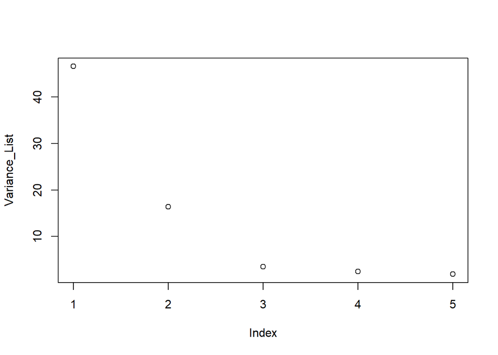

```r
plot(Variance_List)
```

As per the below elbow plot 4 cluster centroid are the best due to strong elbow

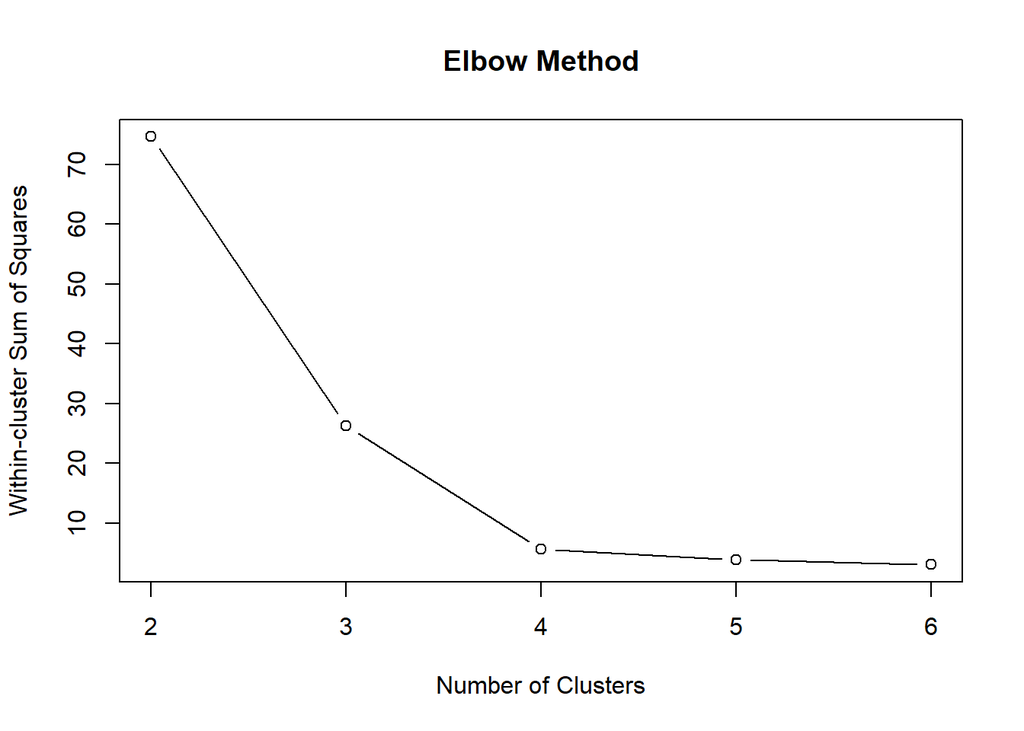

```r
#elbow method
# Perform K-means clustering for different numbers of clusters
wss <- numeric(length = 5)

for (k in 2:6) {
  kmeans_model <- kmeans(scaled_time_data, k, nstart = 10)
  wss[k - 1] <- kmeans_model$tot.withinss
}

#elbow curve
plot(2:6, wss, type = "b", xlab = "Number of Clusters", ylab = "Within-cluster Sum of Squares", main = "Elbow Method")
```

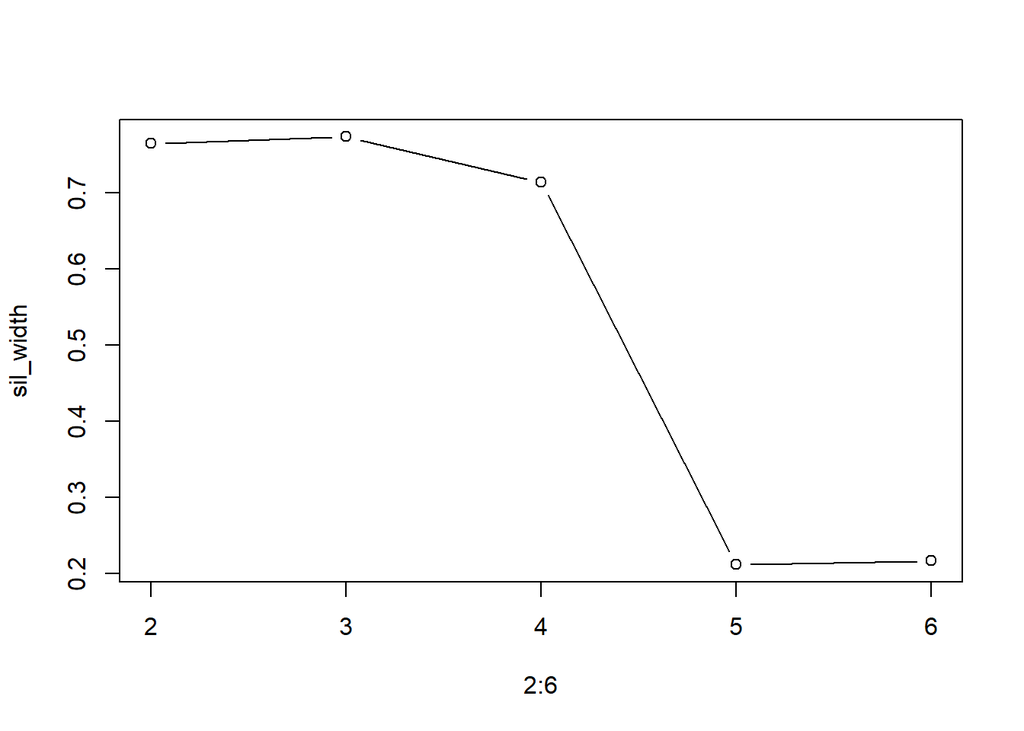

```r
#silhouette method

library(cluster)

sil_width <- numeric(length = 5)

# Computing silhouette widths for different numbers of clusters
for (k in 2:6) {
  # Perform K-means clustering
  kmeans_model <- kmeans(scaled_time_data, k, nstart = 10)

  if (k > 1) {  # Silhouette width using two clusters
    silhouette_width <- silhouette(kmeans_model$cluster, dist(scaled_time_data))
    sil_width[k - 1] <- mean(silhouette_width[, "sil_width"])
  }
}

# Plot the silhouette scores
plot(2:6, sil_width, type = "b")
```

The cluster membership indicates that each data point belongs to one of five distinct groups, with the majority of data points being assigned to clusters 2 and 4. This distribution suggests that there are dominant patterns or behaviors shared among a significant portion of the data, while the remaining clusters represent smaller, possibly more specialized segments.

Further analysis of the characteristics of each cluster can provide insights into the underlying patterns present in the data and guide targeted decision-making or intervention strategies tailored to the needs of each group.

```r
#2. Show the membership for each cluster
optimal_num_clusters <- 5

#K-means clustering with the optimal number of clusters
kmeans_model <- kmeans(scaled_time_data, optimal_num_clusters, nstart = 10)

cluster_membership <- kmeans_model$cluster

# Print the cluster membership for each data point
print(cluster_membership)
```

```
##  [1] 1 4 2 2 4 2 4 4 3 4 2 2 5 2 2 2 4 2 4 4 4
```

As per below observations:

Clusters indicate Cluster 2 and 4 seem to lie towards left bottom

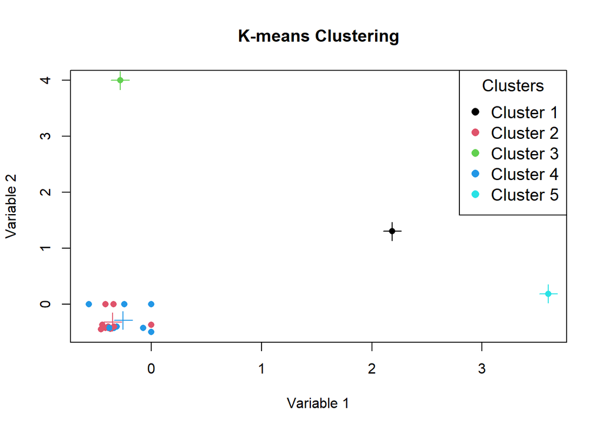

```r
# Scatter plot of the data with clusters colored by membership
plot(scaled_time_data[, 1], scaled_time_data[, 2],
     col = kmeans_model$cluster, pch = 16,
     xlab = "Variable 1", ylab = "Variable 2",
     main = "K-means Clustering")

# Adding cluster centers to the plot
points(kmeans_model$centers[, 1], kmeans_model$centers[, 2], col = 1:optimal_num_clusters, pch = 3, cex = 2)

# Adding legend
legend("topright", legend = paste("Cluster", 1:optimal_num_clusters), col = 1:optimal_num_clusters, pch = 16, cex = 1.2, title = "Clusters")
```

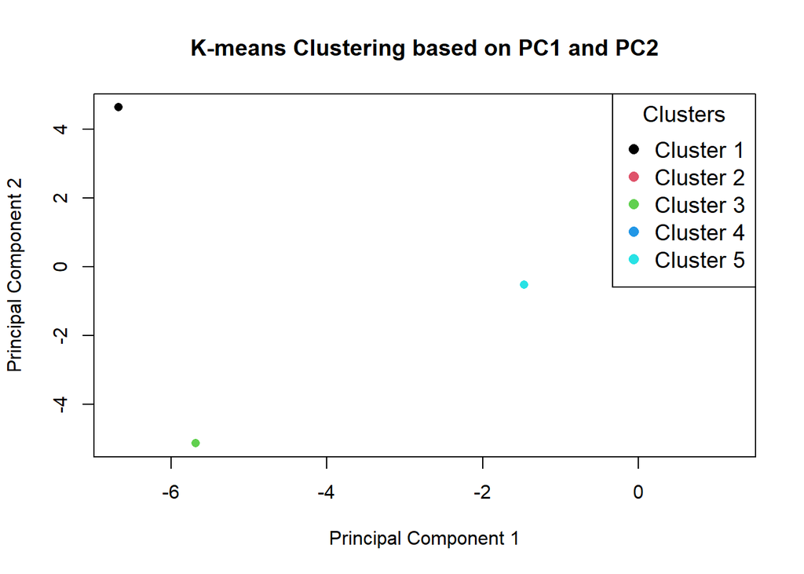

```r
#3. Show a visualization of the cluster and membership using the first two Principal Components.

# Perform PCA
pca_result <- prcomp(scaled_time_data, scale. = TRUE)

# Extract PC scores for the first three principal components
PC1 <- pca_result$x[, 1]
PC2 <- pca_result$x[, 2]
PC3 <- pca_result$x[, 3]

# Plot the data with clusters colored by membership
plot(PC1, PC2,
     col = kmeans_model$cluster, pch = 16,
     xlab = "Principal Component 1", ylab = "Principal Component 2",
     main = "K-means Clustering based on PC1 and PC2")

# Add legend
legend("topright", legend = paste("Cluster", 1:optimal_num_clusters),
       col = 1:optimal_num_clusters, pch = 16, cex = 1.2, title = "Clusters")
```

Cluster 1 (clus1): Low engagement across all platforms, indicating minimal or sporadic activity.

Cluster 5 (clus5): Mixed engagement, with exceptionally high activity on Instagram and relatively lower engagement on other platforms.

```r
# Saving five k-means clusters in a list
# Initialize a list to store matrices for each cluster
cluster_matrices <- list()

# Iterate over each cluster
for (i in 1:max(kmeans5.sm$cluster)) {
     # Subset data for the current cluster
     cluster_indices <- which(kmeans5.sm$cluster == i)
     cluster_data <- scaled_time_data[cluster_indices, ]

     # Store the cluster data in the list
     cluster_matrices[[paste0("clus", i)]] <- cluster_data
 }

# Check the list of matrices
print(cluster_matrices)
```

```
## $clus1
##       Instagram_Time Linkedin_Time Snapchat_Time Twitter_Time Whatsapp_Time
##  [1,]    -0.31450386    -0.4025969    -0.4308111   -0.2674074    -0.5002154
##  [2,]    -0.56791530     0.0000000    -0.6199059    0.0000000    -0.5338406
##  [3,]    -0.39205650    -0.4250718    -0.6199059   -0.2674074    -0.4485936
##  [4,]    -0.33853426    -0.4250718    -0.4658920   -0.2674074    -0.3349310
##  [5,]     0.00000000    -0.4999880    -0.6199059   -0.2674074     0.0000000
##  [6,]    -0.24678184     0.0000000    -0.6199059    0.0000000    -0.2397385
##  [7,]    -0.38222588    -0.4266325    -0.6199059   -0.2674074    -0.3657146
##  [8,]    -0.07583835    -0.4260082    -0.2442832   -0.2674074    -0.1829072
##  [9,]     0.00000000     0.0000000    -0.6199059   -0.2674074     0.3011063
##       Youtube_Time   OTT_Time Reddit_Time
##  [1,]   -0.4104311 -0.4655216  -0.2854977
##  [2,]   -0.4435452  0.0000000   0.0000000
##  [3,]   -0.4656213 -0.4655216  -0.2854977
##  [4,]    0.0000000 -0.4252406  -0.2854977
##  [5,]   -0.4656213 -0.4655216  -0.2854977
##  [6,]   -0.4420735  0.0000000  -0.2854977
##  [7,]   -0.3706942 -0.4655216  -0.2854977
##  [8,]   -0.3699583 -0.3312514  -0.2854977
##  [9,]   -0.5980778 -0.4655216  -0.2854977
##
## $clus2
## Instagram_Time  Linkedin_Time  Snapchat_Time   Twitter_Time  Whatsapp_Time
##     -0.2844659      3.9949878      4.1031869     -0.2674074      3.5750646
##   Youtube_Time       OTT_Time    Reddit_Time
##      3.6405294      0.5012237     -0.2854977
##
## $clus3
##       Instagram_Time Linkedin_Time Snapchat_Time Twitter_Time Whatsapp_Time
##  [1,]     -0.4444865    -0.3688846             0   -0.2674074    -0.3396669
##  [2,]     -0.3915104    -0.4004118             0   -0.2674074    -0.4684846
##  [3,]      0.0000000    -0.3688846             0   -0.2674074    -0.2780996
##  [4,]     -0.4177253     0.0000000             0   -0.1745354     0.0000000
##  [5,]     -0.4586862    -0.4531654             0   -0.1585229    -0.5148968
##  [6,]     -0.3713030    -0.4438008             0    0.0000000    -0.5220008
##  [7,]     -0.4155408    -0.4297540             0   -0.2674074    -0.4343858
##  [8,]     -0.3385343    -0.4063427             0   -0.2674074    -0.4770093
##  [9,]     -0.3450880     0.0000000             0   -0.2674074    -0.4215987
##       Youtube_Time   OTT_Time Reddit_Time
##  [1,]    0.0000000  0.0000000  -0.2854977
##  [2,]    0.0000000  0.0000000  -0.2854977
##  [3,]   -0.2890127 -0.4252406  -0.2854977
##  [4,]    0.0000000 -0.4655216  -0.2854977
##  [5,]   -0.4876974  0.0000000  -0.2854977
##  [6,]   -0.4876974  0.0000000  -0.2854977
##  [7,]   -0.4597344  0.0000000   0.2514085
##  [8,]   -0.3773170  0.0000000   0.0000000
##  [9,]    0.0000000 -0.4324016  -0.2854977
##
## $clus4
## Instagram_Time  Linkedin_Time  Snapchat_Time   Twitter_Time  Whatsapp_Time
##     2.18465722     1.29800232     0.61220524     4.34416932     0.06288835
##   Youtube_Time       OTT_Time    Reddit_Time
##     2.05105173     4.20708085     4.31655539
##
## $clus5
## Instagram_Time  Linkedin_Time  Snapchat_Time   Twitter_Time  Whatsapp_Time
##     3.60053901     0.18362289     0.14502975    -0.26740740     2.12302410
##   Youtube_Time       OTT_Time    Reddit_Time
##    -0.02409972    -0.30104064     0.00000000
```

```r
#Factor Analysis
library(psych)
fit.pc_sm <- principal(scaled_time_data, nfactors=4, rotate="varimax")
fit.pc_sm
```

```
## Principal Components Analysis
## Call: principal(r = scaled_time_data, nfactors = 4, rotate = "varimax")
## Standardized loadings (pattern matrix) based upon correlation matrix
##                 RC1   RC2   RC3   RC4   h2     u2 com
## Instagram_Time 0.10  0.34  0.93  0.00 1.00 0.0019 1.3
## Linkedin_Time  0.96  0.21  0.03  0.14 0.99 0.0056 1.1
## Snapchat_Time  0.98  0.06 -0.02 -0.20 1.00 0.0029 1.1
## Twitter_Time   0.08  0.98  0.15  0.05 0.99 0.0056 1.1
## Whatsapp_Time  0.87 -0.15  0.45  0.11 0.99 0.0060 1.6
## Youtube_Time   0.91  0.39  0.02 -0.02 0.98 0.0207 1.4
## OTT_Time       0.25  0.96  0.10 -0.06 0.99 0.0107 1.2
## Reddit_Time    0.08  0.97  0.20  0.00 0.99 0.0104 1.1
##
##                        RC1  RC2  RC3  RC4
## SS loadings           3.55 3.16 1.15 0.08
## Proportion Var        0.44 0.39 0.14 0.01
## Cumulative Var        0.44 0.84 0.98 0.99
## Proportion Explained  0.45 0.40 0.14 0.01
## Cumulative Proportion 0.45 0.85 0.99 1.00
##
## Mean item complexity =  1.2
## Test of the hypothesis that 4 components are sufficient.
##
## The root mean square of the residuals (RMSR) is  0
##  with the empirical chi square  0.01  with prob <  0.99
##
## Fit based upon off diagonal values = 1
```

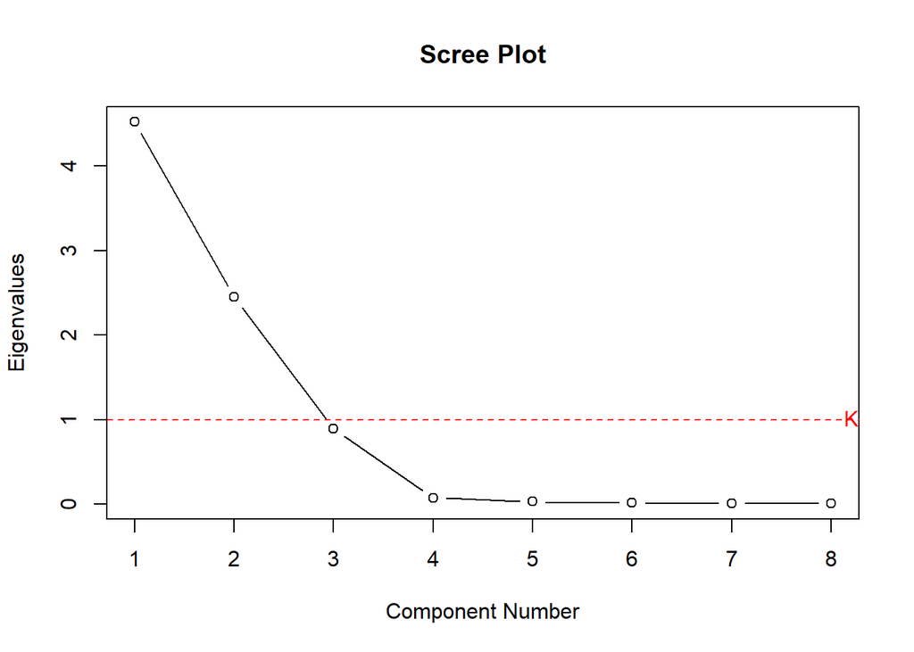

```r
# Extract eigenvalues
eigenvalues <- fit.pc_sm$values
# Create scree plot
plot(1:length(eigenvalues), eigenvalues, type="b",
      xlab="Component Number", ylab="Eigenvalues", main="Scree Plot")
# Add a horizontal line at y = 1 for reference (Kaiser's criterion)
abline(h=1, col="red", lty=2)
# Add text label for Kaiser's criterion
text(length(eigenvalues), 1, "Kaiser's Criterion (Eigenvalue = 1)", pos=4, col="red")
```